# Lab 7: July 21

POLS 3316, Summer 2022, University of Houston, Instructor: Tom Hanna

## Part 1 - Loading data

This data came from Data World:

https://data.world/datasets/open-data

If you haven’t found a data set and want to use **fictional data** as long as it has at least two appropriate variables - **go for it!**

### Game of Thrones Screen Times

*Dataset compiled by Aendrew Rininsland Author of “Learning D3.js Data Visualization” from Packt Publishing, journo-coder at Financial Times http://æ.ninja/

First, I spent about 20 minutes figuring out how to load the JSON data, mostly because I hadn’t done that before:

```r
library(here) #This library helps with finding the
#data file on the local computer
#install.packages("rjson") #install on first use
#library("rjson") #load the libary to import the json data type

#install.packages("jsonlite")
library(jsonlite)
gotdatajson <- fromJSON(here("data","GoT-screentimes.json"))
# Note the rjson file package also allows reading this #file type directly from a website
```

The author also provided CSV data and that took about 20 seconds:

```r
gotdatacsv <- read.csv(here("data","GOT_screentimes.csv"))
```

Exploring the data:

```r
head(gotdatacsv)
```

|  | name | imdb_url | screentime | episodes | portrayed_by_name | portrayed_by_imdb_url |
| --- | --- | --- | --- | --- | --- | --- |
| 1 | Tyrion Lannister | http://www.imdb.com/character/ch0146096/ | 293.30 | 54 | Peter Dinklage | http://www.imdb.com/name/nm0227759/ |
| 2 | Jon Snow | http://www.imdb.com/character/ch0155777/ | 268.15 | 49 | Kit Harington | http://www.imdb.com/name/nm3229685/ |
| 3 | Daenerys Targaryen | http://www.imdb.com/character/ch0158597/ | 221.30 | 49 | Emilia Clarke | http://www.imdb.com/name/nm3592338/ |
| 4 | Cersei Lannister | http://www.imdb.com/character/ch0159526/ | 201.45 | 52 | Lena Headey | http://www.imdb.com/name/nm0372176/ |
| 5 | Sansa Stark | http://www.imdb.com/character/ch0158137/ | 199.30 | 47 | Sophie Turner | http://www.imdb.com/name/nm3849842/ |
| 6 | Arya Stark | http://www.imdb.com/character/ch0158604/ | 189.15 | 47 | Maisie Williams | http://www.imdb.com/name/nm3586035/ |

```r
NA
```

```r
names(gotdatacsv)
```

```
[1] "name"                  "imdb_url"
[3] "screentime"            "episodes"
[5] "portrayed_by_name"     "portrayed_by_imdb_url"
```

Use the indexes to print one variable (column 1)

```r
gotdatacsv[1]
```

| name |
| --- |
| Tyrion Lannister |
| Jon Snow |
| Daenerys Targaryen |
| Cersei Lannister |
| Sansa Stark |
| Arya Stark |
| Jaime Lannister |
| Theon Greyjoy |
| Samwell Tarly |
| Jorah Mormont |

[output cut: 181 more lines]

Use variable names to do the same thing:

```r
gotdatacsv$portrayed_by_name
```

```
  [1] "Peter Dinklage"            "Kit Harington"
  [3] "Emilia Clarke"             "Lena Headey"
  [5] "Sophie Turner"             "Maisie Williams"
  [7] "Nikolaj Coster-Waldau"     "Alfie Allen"
  [9] "John Bradley"              "Iain Glen"
 [11] "Aidan Gillen"              "Sean Bean"
 [13] "Gwendoline Christie"       "Liam Cunningham"
 [15] "Isaac Hempstead Wright"    "Michelle Fairley"
 [17] "Conleth Hill"              "Charles Dance"
 [19] "Natalie Dormer"            "Richard Madden"
 [21] "Stephen Dillane"           "Rory McCann"
 [23] "Jack Gleeson"              "Iwan Rheon"
 [25] "Carice van Houten"         "Jerome Flynn"
 [27] "Hannah Murray"             "Rose Leslie"
 [29] "Sibel Kekilli"             "Ed Skrein"
```

[output cut: 81 more lines]

Run “summary” on a character variable

```r
summary(gotdatacsv$name)
```

```
   Length     Class      Mode
      191 character character
```

Summary on a numeric variable:

```r
summary(gotdatacsv$screentime)
```

```
   Min. 1st Qu.  Median    Mean 3rd Qu.    Max.
  1.150   4.375  10.300  27.261  27.650 293.300
```

Correlation (tomorrow’s topic)

```r
#get correlation of episodes and screentime
#cor(gotdatacsv$episodes,gotdatacsv$screentime)
```

```r
#create a new numeric variable from the character variable
gotdatacsv$screentime_numeric <- as.numeric(gotdatacsv$screentime)
gotdatacsv$episodes_numeric <- as.numeric(gotdatacsv$episodes)
#run correlation with the new variable
cor(gotdatacsv$episodes_numeric,gotdatacsv$screentime_numeric)
```

```
[1] NA
```

Because there are NAs in the data, it can’t compute the correlation. (Sometimes this will give an NA and sometimes it will just give an error.)

```r
#Using pairwise complete observations to eliminate NA instances
cor(gotdatacsv$episodes_numeric,gotdatacsv$screentime_numeric, use = "pairwise.complete.obs")
```

```
[1] 0.8959364
```

I want to plot the screentime to see the distribution

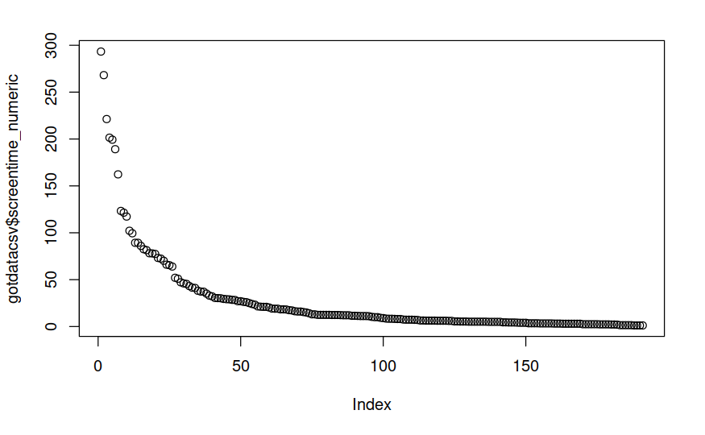

```r
#plot the screentime
plot(gotdatacsv$screentime_numeric)
```

This isn’t really surprising ecause you can’t go below 0, minor characters approach zero, and major characters drop like flies. This is actually a “survival function” distribution.

Plotting episodes vs screen time:

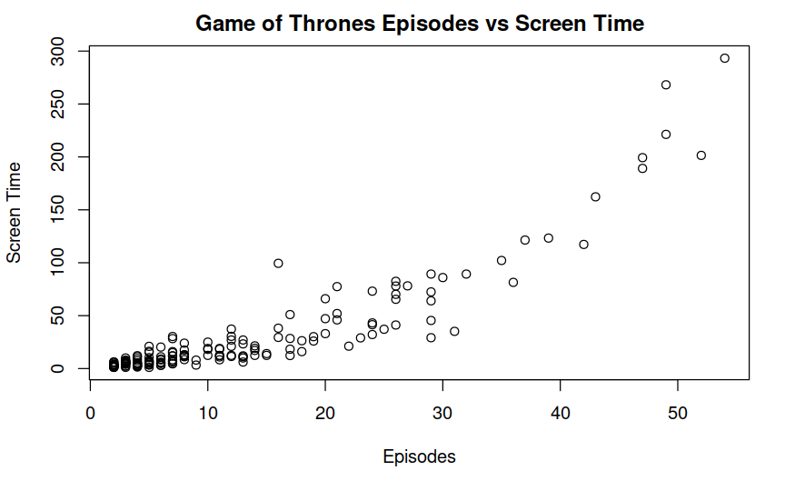

```r
plot(gotdatacsv$episodes_numeric,gotdatacsv$screentime_numeric, main = "Game of Thrones Episodes vs Screen Time", xlab = "Episodes", ylab = "Screen Time")
```

## Part 2 - Frequency distributions

We’re going to use some sample data on measurements of body dimensions from 247 men and 260 women, mostly healthy young adults.

```r
#Loading data from URL
load(url("http://www.openintro.org/stat/data/bdims.RData"))

#look at the variables etc
head(bdims)
```

|  | bia.di | bii.di | bit.di | che.de | che.di | elb.di | wri.di | kne.di | ank.di | sho.gi | che.gi | wai.gi | nav.gi | hip.gi | thi.gi | bic.gi | for.gi | kne.gi | cal.gi | ank.gi | wri.gi | age | wgt | hgt | sex |
| --- | --- | --- | --- | --- | --- | --- | --- | --- | --- | --- | --- | --- | --- | --- | --- | --- | --- | --- | --- | --- | --- | --- | --- | --- | --- |
| 1 | 42.9 | 26.0 | 31.5 | 17.7 | 28.0 | 13.1 | 10.4 | 18.8 | 14.1 | 106.2 | 89.5 | 71.5 | 74.5 | 93.5 | 51.5 | 32.5 | 26.0 | 34.5 | 36.5 | 23.5 | 16.5 | 21 | 65.6 | 174.0 | 1 |
| 2 | 43.7 | 28.5 | 33.5 | 16.9 | 30.8 | 14.0 | 11.8 | 20.6 | 15.1 | 110.5 | 97.0 | 79.0 | 86.5 | 94.8 | 51.5 | 34.4 | 28.0 | 36.5 | 37.5 | 24.5 | 17.0 | 23 | 71.8 | 175.3 | 1 |
| 3 | 40.1 | 28.2 | 33.3 | 20.9 | 31.7 | 13.9 | 10.9 | 19.7 | 14.1 | 115.1 | 97.5 | 83.2 | 82.9 | 95.0 | 57.3 | 33.4 | 28.8 | 37.0 | 37.3 | 21.9 | 16.9 | 28 | 80.7 | 193.5 | 1 |
| 4 | 44.3 | 29.9 | 34.0 | 18.4 | 28.2 | 13.9 | 11.2 | 20.9 | 15.0 | 104.5 | 97.0 | 77.8 | 78.8 | 94.0 | 53.0 | 31.0 | 26.2 | 37.0 | 34.8 | 23.0 | 16.6 | 23 | 72.6 | 186.5 | 1 |
| 5 | 42.5 | 29.9 | 34.0 | 21.5 | 29.4 | 15.2 | 11.6 | 20.7 | 14.9 | 107.5 | 97.5 | 80.0 | 82.5 | 98.5 | 55.4 | 32.0 | 28.4 | 37.7 | 38.6 | 24.4 | 18.0 | 22 | 78.8 | 187.2 | 1 |
| 6 | 43.3 | 27.0 | 31.5 | 19.6 | 31.3 | 14.0 | 11.5 | 18.8 | 13.9 | 119.8 | 99.9 | 82.5 | 80.1 | 95.3 | 57.5 | 33.0 | 28.0 | 36.6 | 36.1 | 23.5 | 16.9 | 21 | 74.8 | 181.5 | 1 |

```r
names(bdims)
```

```
 [1] "bia.di" "bii.di" "bit.di" "che.de" "che.di" "elb.di" "wri.di"
 [8] "kne.di" "ank.di" "sho.gi" "che.gi" "wai.gi" "nav.gi" "hip.gi"
[15] "thi.gi" "bic.gi" "for.gi" "kne.gi" "cal.gi" "ank.gi" "wri.gi"
[22] "age"    "wgt"    "hgt"    "sex"
```

Unfortunately the publisher deleted the codebook, but we only need the obvious variables: *age* [22], weight in kg *wgt* [23], height in cm *hgt* [24], and sex [1 is male, 0 is female].

For comparison and practice purposes, we’re going to subset this into two data frames - one for males (mdims) and one for females (fdims). We use the *relational operator* == to tell R that we want sex to equal 1 for the male set and 0 for the female set:

```r
#create dataframe mdims as subset of bdims where the bdims variable sex is equal to 1
mdims <- subset(bdims, bdims$sex == 1)

#create dataframe fdims as subset of bdims where the bdims variable sex is equal to 0
fdims <- subset(bdims, bdims$sex == 0)
```

We’ll plot a histogram of men’s height and women’s height to compare the distributions: